# Rumination, Emotion Induction Mechanisms and Sad Music

Joel Larwood

```r
library(corplot)
```

[output not shown]

The code to clean the orginal data can be seen here and run with the following code chunk

```r
source(here::here("code", "RMER_November18_Process.R"))
```

# Data joins

The data from spotify and the data from self report were joined together

# Descriptives of data

## Demographic Measures

### Age

The mean age was 21.9 with a standard deviation of 2.3

### Gender

The gender counts can be seen in the table below.

```r
data_dropped %>%
  group_by(gender) %>%
  summarise(gender_count = n()) %>%
  knitr::kable(format = "html") %>%
  kableExtra::kable_styling()
```

| gender | gender_count |
| --- | --- |
| male | 162 |
| female | 212 |
| neither | 3 |

## Trait measures

1. Rumination
2. MUSEBAQ - Emotion and Cognitive regulation

```r
data_dropped %>%
  select(rumination, musebaq) %>%
  psych::describe() %>%
    select(n, mean, sd, min, max) %>%
  knitr::kable(digits =2,
               format = "html") %>%
  kableExtra::kable_styling()
```

|  | n | mean | sd | min | max |
| --- | --- | --- | --- | --- | --- |
| rumination | 377 | 3.87 | 0.69 | 1.33 | 5 |
| musebaq | 377 | 32.49 | 7.86 | 9.00 | 45 |

Additionally the internal consistency for a) rumination was good, 0.91  
b) the emotion and cognitive regulation scale of the MUSEBAQ was also good 0.91

# Correlation Matrix

```
Means, standard deviations, and correlations with confidence intervals


  Variable       M     SD   1            2            3            4
  1. rumination  3.86  0.70

  2. musebaq     32.56 7.85 .31**
                            [.22, .40]

  3. Baseline    9.50  5.06 .25**        .18**
                            [.16, .34]   [.08, .28]

  4. mecscale_1  1.75  0.43 -.03         -.02         -.15**
                            [-.13, .07]  [-.12, .08]  [-.25, -.05]

  5. mecscale_2  1.20  0.40 -.07         -.12*        -.07         .09
                            [-.17, .03]  [-.21, -.02] [-.17, .03]  [-.01, .19]

  6. mecscale_3  1.33  0.47 -.10*        -.19**       -.15**       .09
                            [-.20, -.00] [-.29, -.09] [-.25, -.05] [-.01, .19]

  7. mecscale_4  1.26  0.44 -.09         -.12*        -.00         -.07
                            [-.19, .01]  [-.22, -.02] [-.10, .10]  [-.17, .03]

  8. mecscale_5  1.23  0.42 -.02         -.08         -.02         .06
                            [-.12, .08]  [-.18, .02]  [-.12, .08]  [-.04, .16]

  9. mecscale_6  1.08  0.27 -.10         -.16**       .02          .04
                            [-.19, .00]  [-.25, -.06] [-.08, .12]  [-.06, .14]

  10. mecscale_7 1.88  0.32 .01          .01          -.15**       .10
                            [-.09, .11]  [-.09, .11]  [-.24, -.05] [-.00, .20]

  11. mecscale_8 1.84  0.36 -.02         -.15**       -.12*        .12*
                            [-.12, .08]  [-.24, -.05] [-.22, -.02] [.02, .22]

  5           6            7           8           9           10



```

[output cut: 20 more lines]

```
  .12*        -.02         .09         .18**
  [.02, .21]  [-.12, .08]  [-.01, .19] [.08, .28]

  -.03        .02          -.01        .02         .02
  [-.13, .07] [-.08, .12]  [-.11, .09] [-.09, .12] [-.08, .12]

  .14**       .10*         .06         .11*        -.00        .07
  [.04, .24]  [.00, .20]   [-.04, .16] [.01, .21]  [-.10, .10] [-.03, .17]


Note. M and SD are used to represent mean and standard deviation, respectively.
Values in square brackets indicate the 95% confidence interval.
The confidence interval is a plausible range of population correlations
that could have caused the sample correlation (Cumming, 2014).
* indicates p < .05. ** indicates p < .01.
```

```r
cowplot::plot_grid(shade, num)
```

[output not shown]

# Manipulation Check

```r
apa::t_apa(apa::t_test(data$PostInduction, data$Baseline, paired = TRUE), format = "markdown")
```

```
*t*(382) = 14.02, *p* < .001, *d* = 0.72
```

The induction of sadness was succesful, *t*(382) = 14.02, *p* < .001, *d* = 0.72

# Pre-to-Post testing

```r
Nov18Long <- data %>%
  select(ResponseId,
         musebaq:Appraisal) %>%
  pivot_longer(cols = PostInduction:PostListening,
               names_to = "Timepoint",
               names_ptypes = factor(),
               values_to = "Sadness") %>%
  mutate(Timepoint = fct_relevel(Timepoint,
                                "PostInduction"))
```

## Hypothesis Test

We predicted that sadness would decrease from pre to post listening and that rumination would not influence this.

```r
prepost <- apa::t_apa(apa::t_test(data$PostListening, data$PostInduction, paired = TRUE), format = "markdown")
```

```
*t*(382) = 6.37, *p* < .001, *d* = 0.33
```

This was not the case, with sadness increasing when not accounting for rumination, *t*(382) = 6.37, *p* < .001, *d* = 0.33, and an intertaction between timepoint and rumination

```r
PostInductionTimePoints <- lmerTest::lmer(Sadness~1 + Timepoint  + rumination + Timepoint:rumination + (1|ResponseId), data = Nov18Long)

sjPlot::tab_model(PostInductionTimePoints,
                  show.std = TRUE,
                  show.aic = TRUE,
                  show.df = TRUE
                  )
```

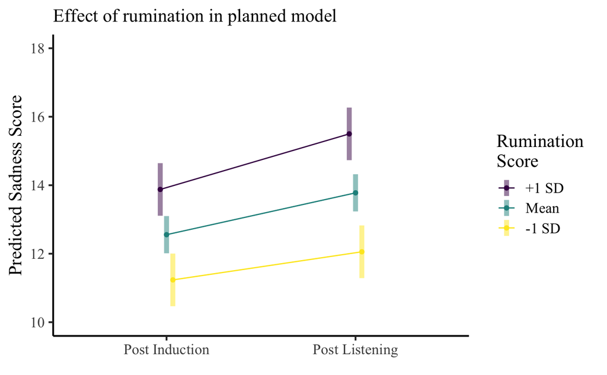

```r
DummyLong <- Nov18Long %>%
  mutate(Dummy = if_else(Timepoint == "PostInduction", 0, 1))

jn <- interactions::johnson_neyman(model = lmerTest::lmer(Sadness~1 + Dummy  + rumination + Dummy:rumination + (1|ResponseId), data = DummyLong),
                             pred = "Dummy",
                             modx = "rumination")


upperJN <- jn$bounds[[2]]
```

Johnson-Neyman intervals showed that the rumination did not predict increased sadness at post listening when scores were less that 2.866

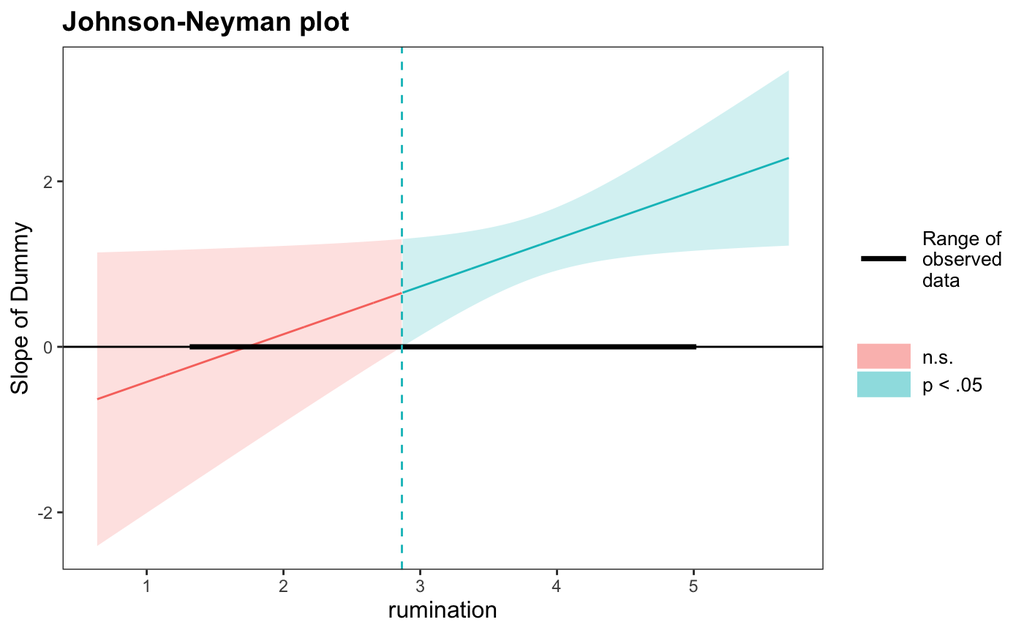

```r
jn$plot
```

## Exploring the role of traits

To explore the role of traits we did a greedy stepback regression using `buildmer`. All interactions between traits, including baseline mood (as a depression proxy), were included.

```r
traitexplore <- buildmer::buildmer(formula = Sadness~ 1+Timepoint*Baseline + Timepoint*musebaq +Timepoint*rumination + (1 | ResponseId),
                                   data = Nov18Long,
                                   direction='backward',
                                   na.action=na.exclude,
                                   control=lmerControl(optimizer='bobyqa'))@model

sjPlot::tab_model(traitexplore)
```

## Exploring the role of BRECVEMA mechanisms

```r
sjPlot::tab_model(BRECVEMAexplore,
                  show.std = TRUE,
                  pred.labels = FALSE)
```

```
Length of `pred.labels` does not equal number of predictors, no labelling applied.
```

## All predictors

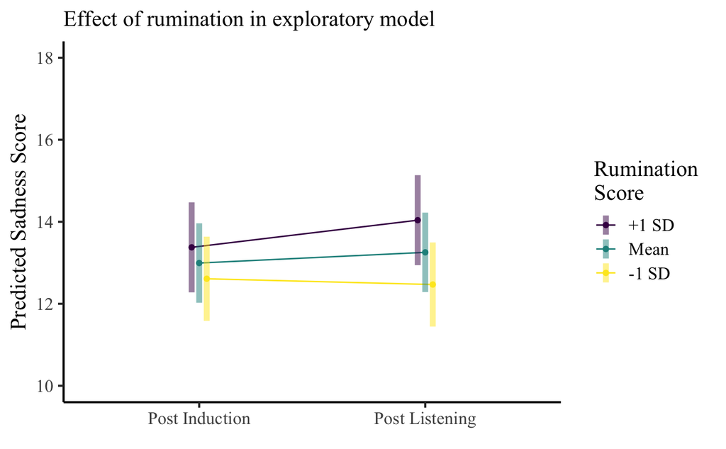

Johnson-neyman intervals for exploratory models

```
JOHNSON-NEYMAN INTERVAL

When rumination is OUTSIDE the interval [-0.32, 31.46], the slope of
Dummy is p < .05.

Note: The range of observed values of rumination is [1.33, 5.00]
```

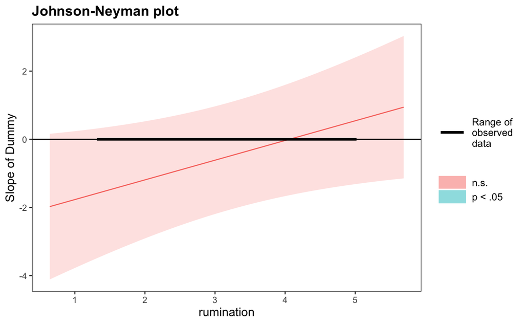

```r
interactions::johnson_neyman(model =
                               lmerTest::lmer(Sadness ~ 1 + Dummy + BSR + Dummy:BSR + Entrainment + Contagion + Dummy:Contagion + Imagery + Memory + Dummy:Memory + Appraisal + Dummy:Appraisal + Baseline + Dummy:Baseline + rumination + Dummy:rumination + (1 | ResponseId),
                                              data = DummyLong),
                             pred = Dummy,
                             modx = rumination
                             )
```

## Compariosn of all models

```r
cbind(
  AIC(PostInductionTimePoints, traitexplore, BRECVEMAexplore, AllExplore),
  BIC(PostInductionTimePoints, traitexplore, BRECVEMAexplore, AllExplore)
)[,c(1,2,4)]
```

[output not shown]

```r
sjPlot::tab_model(PostInductionTimePoints,
                  AllExplore,
                  show.est = TRUE,
                  show.std = TRUE,
                  show.fstat = TRUE,
                  pred.labels = FALSE)
```

```
Length of `pred.labels` does not equal number of predictors, no labelling applied.
```

# Rumination across planned and stepback models

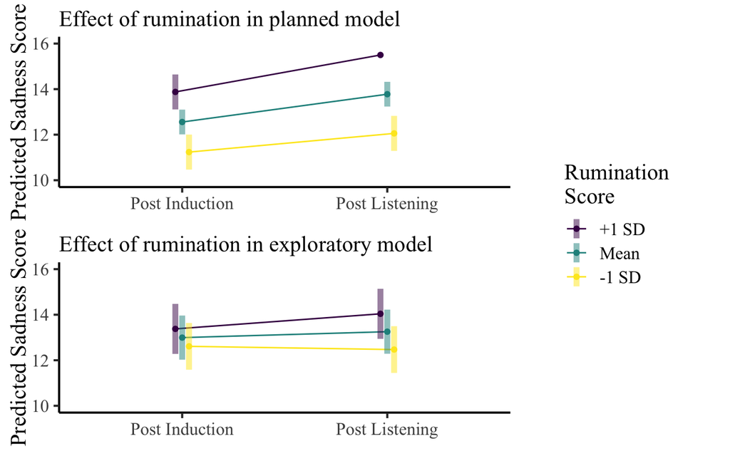

Rumination slopes

```r
NoMech <- emmeans::emmeans(AllExplore,
                           ~rumination*Timepoint,
                           at = (list(rumination = c(minrum, plusrum, meanrum),
                                      Timepoint = c("PostInduction",
                                                    "PostListening"),
                                      Contagion = "No",
                                      Entrainment = "No",
                                      BSR = "No",
                                      Memory = "No",
                                      Imagery = "No",
                                      Appraisal = "No")))

emmeans::contrast(NoMech,
                  "pairwise",
                  by = "rumination")
```

```
rumination = 3.16:
 contrast                      estimate    SE  df t.ratio p.value
 PostInduction - PostListening    1.257 0.730 372 1.723   0.0860

rumination = 4.55:
 contrast                      estimate    SE  df t.ratio p.value
 PostInduction - PostListening    0.453 0.775 372 0.585   0.5590

rumination = 3.86:
 contrast                      estimate    SE  df t.ratio p.value
 PostInduction - PostListening    0.855 0.726 372 1.178   0.2400
```

```r
AllMech <- emmeans::emmeans(AllExplore,
                            ~rumination*Timepoint,
                            at = (list(rumination = c(minrum, plusrum, meanrum),
                                       Timepoint = c("PostInduction",
                                                     "PostListening"),
                                       Contagion = "Yes",
                                       Entrainment = "Yes",
                                       BSR = "Yes",
                                       Memory = "Yes",
                                       Imagery = "Yes",
                                       Appraisal = "Yes")))
emmeans::contrast(AllMech,
                  "pairwise",
                  by = c("rumination"))
```

```
rumination = 3.16:
 contrast                      estimate    SE  df t.ratio p.value
 PostInduction - PostListening   -0.975 0.612 372 -1.593  0.1121

rumination = 4.55:
 contrast                      estimate    SE  df t.ratio p.value
 PostInduction - PostListening   -1.778 0.601 372 -2.958  0.0033

rumination = 3.86:
 contrast                      estimate    SE  df t.ratio p.value
 PostInduction - PostListening   -1.376 0.573 372 -2.400  0.0169
```

```r
ContOnly <- emmeans::emmeans(AllExplore,
                                   ~rumination*Timepoint,
                                   at = (list(rumination = c(minrum, plusrum, meanrum),
                                              Timepoint = c("PostListening",
                                                            "PostInduction"),
                                              Contagion = "Yes",
                                              Entrainment = "No",
                                              BSR = "No",
                                              Memory = "No",
                                              Imagery = "No",
                                              Appraisal = "No")))
emmeans::contrast(ContOnly,
                  "pairwise",
                  by = c("rumination"))
```

```
rumination = 3.16:
 contrast                      estimate    SE  df t.ratio p.value
 PostListening - PostInduction   -0.376 0.705 372 -0.533  0.5940

rumination = 4.55:
 contrast                      estimate    SE  df t.ratio p.value
 PostListening - PostInduction    0.428 0.734 372  0.583  0.5600

rumination = 3.86:
 contrast                      estimate    SE  df t.ratio p.value
 PostListening - PostInduction    0.026 0.692 372  0.037  0.9700
```

```r
ContApp <- emmeans::emmeans(AllExplore,
                                   ~rumination*Timepoint,
                                   at = (list(rumination = c(minrum, plusrum, meanrum),
                                              Timepoint = c("PostListening",
                                                            "PostInduction"),
                                              Contagion = "Yes",
                                              Entrainment = "No",
                                              BSR = "No",
                                              Memory = "No",
                                              Imagery = "No",
                                              Appraisal = "Yes")))
emmeans::contrast(ContApp,
                  "pairwise",
                  by = c("rumination"))
```

```
rumination = 3.16:
 contrast                      estimate    SE  df t.ratio p.value
 PostListening - PostInduction    -1.51 0.830 372 -1.824  0.0690

rumination = 4.55:
 contrast                      estimate    SE  df t.ratio p.value
 PostListening - PostInduction    -0.71 0.854 372 -0.832  0.4060

rumination = 3.86:
 contrast                      estimate    SE  df t.ratio p.value
 PostListening - PostInduction    -1.11 0.818 372 -1.359  0.1750
```

Plot scenarios

[figure not shown]